# Analysis of the 2020-2021 Premier League Season

## Introduction

The Premier League, often referred to outside the UK as the English Premier League, or sometimes the EPL, is the top level of the English football league system. Contested by 20 clubs, it operates on a system of promotion and relegation with the English Football League.

In this project, I have attempted to visualize a few of the most common football stats as seen on major sports channels and publications. The raw used can be found on [this](http://www.football-data.co.uk/englandm.php) website

## Getting and Cleaning the Data

Fetching the data from the github repository

```r
full.data <- read.csv("https://raw.githubusercontent.com/rohanprad/Data-Science-Project/main/Dataset/PL20-21.csv")
```

Selecting only relevant observations

```r
library(dplyr)

tidy.data <- select(full.data, Date:AR)
tidy.data <- select(tidy.data, -(Time))
tidy.data <- select(tidy.data, -(Referee))
```

Getting the List of the 20 Team Names

```r
clubs <- unique(tidy.data$HomeTeam)
```

Then I defined a function called [getTeamData()](https://github.com/rohanprad/Data-Science-Project/blob/main/TidyingUpTheData.R) which was used to summarize the results of all the matches and return a single row dataframe of relevant data columns for each team

Then I created an empty dataframe (the league table) to store the final results for all 20 teams

```r
league.table <- data.frame(matrix(nrow = 0, ncol = 27))
colnames(league.table) <- c("Club", "P", "W", "D", "L", "GD", "Pts", "GF", "GA",
                            "GF.Avg", "GA.Avg", "HW", "HD", "HL", "HW.Rate",
                            "AW", "AD", "AL", "AW.Rate", "W.Rate", "S", "ST",
                            "C", "F", "B", "YC", "RC")
for(club in clubs){
  row <- getTeamData(club)
  league.table <- rbind(league.table, row)
}
```

Adding a new column for each team defining the team colours

```r
league.table <- arrange(league.table, Club)


teamColors <- c("#EF0107", "#95BFE5", "#0057B8", "#6C1D45", "#034694", "#A7A5A6",
                "#003399", "#000000", "#FFCD00", "#003090", "#9C1310", "#6CABDD",
                "#DA291C", "#241F20", "#EE2737", "#D71920", "#132257", "#122F67",
                "#7A263A", "#FDB913")

league.table$Col = teamColors
```

Arranging the league table by points > goal difference > goals for

```r
league.table <- arrange(league.table, desc(Pts), desc(GD), desc(GF))
```

Converting the clubs column into a factor

```r
league.table <- mutate(league.table, Club = as.factor(league.table$Club))
```

Creating a CSV file to store the final tidy data

```r
write.csv(league.table, file = "./Dataset/TidyData.csv")
```

## Performing Statistical Tests

```r
summary(league.table)
```

```
##              Club          P            W               D
##  Arsenal       : 1   Min.   :28   Min.   : 3.00   Min.   : 2.0
##  Aston Villa   : 1   1st Qu.:29   1st Qu.: 7.75   1st Qu.: 5.0
##  Brighton      : 1   Median :29   Median :12.00   Median : 7.0
##  Burnley       : 1   Mean   :29   Mean   :11.10   Mean   : 6.8
##  Chelsea       : 1   3rd Qu.:29   3rd Qu.:14.00   3rd Qu.: 9.0
##  Crystal Palace: 1   Max.   :30   Max.   :22.00   Max.   :11.0
##  (Other)       :14
##        L               GD              Pts              GF
##  Min.   : 3.00   Min.   :-37.00   Min.   :14.00   Min.   :16.00
##  1st Qu.: 8.75   1st Qu.:-15.00   1st Qu.:32.75   1st Qu.:28.00
##  Median :11.00   Median :  0.50   Median :40.00   Median :39.50
##  Mean   :11.10   Mean   :  0.00   Mean   :40.10   Mean   :37.95
##  3rd Qu.:14.00   3rd Qu.: 13.75   3rd Qu.:48.25   3rd Qu.:45.75
##  Max.   :23.00   Max.   : 43.00   Max.   :71.00   Max.   :64.00
##
##        GA            GF.Avg          GA.Avg           HW             HD
##  Min.   :21.00   Min.   :0.600   Min.   :0.70   Min.   : 2.0   Min.   :1.00
##  1st Qu.:32.00   1st Qu.:1.000   1st Qu.:1.10   1st Qu.: 4.0   1st Qu.:2.00
##  Median :36.50   Median :1.400   Median :1.25   Median : 5.0   Median :3.00
##  Mean   :37.95   Mean   :1.320   Mean   :1.31   Mean   : 5.4   Mean   :3.40
##  3rd Qu.:47.00   3rd Qu.:1.625   3rd Qu.:1.60   3rd Qu.: 7.0   3rd Qu.:4.25
##  Max.   :57.00   Max.   :2.100   Max.   :2.00   Max.   :12.0   Max.   :7.00
##
##        HL           HW.Rate            AW             AD            AL
##  Min.   : 2.00   Min.   :12.00   Min.   : 1.0   Min.   :0.0   Min.   : 0.00
##  1st Qu.: 4.75   1st Qu.:28.50   1st Qu.: 4.0   1st Qu.:3.0   1st Qu.: 3.75
##  Median : 6.00   Median :36.00   Median : 6.0   Median :3.0   Median : 5.00
##  Mean   : 5.70   Mean   :37.35   Mean   : 5.7   Mean   :3.4   Mean   : 5.40
##  3rd Qu.: 6.25   3rd Qu.:50.00   3rd Qu.: 7.0   3rd Qu.:4.0   3rd Qu.: 7.00
##  Max.   :11.00   Max.   :75.00   Max.   :10.0   Max.   :7.0   Max.   :12.00
##
##     AW.Rate         W.Rate           S               ST              C
##  Min.   : 7.0   Min.   :10.0   Min.   :237.0   Min.   : 77.0   Min.   :101.0
##  1st Qu.:27.0   1st Qu.:27.0   1st Qu.:282.8   1st Qu.:105.5   1st Qu.:122.0
##  Median :41.5   Median :41.0   Median :347.0   Median :116.5   Median :141.0
##  Mean   :39.3   Mean   :38.2   Mean   :339.6   Mean   :122.0   Mean   :144.6
##  3rd Qu.:47.0   3rd Qu.:48.0   3rd Qu.:381.0   3rd Qu.:142.5   3rd Qu.:166.2
##  Max.   :71.0   Max.   :73.0   Max.   :471.0   Max.   :177.0   Max.   :199.0
##
##        F               B               YC              RC
##  Min.   :268.0   Min.   :30.00   Min.   :30.00   Min.   :0.00
##  1st Qu.:303.5   1st Qu.:38.75   1st Qu.:38.00   1st Qu.:0.00
##  Median :312.0   Median :44.00   Median :41.00   Median :1.50
##  Mean   :318.6   Mean   :43.75   Mean   :42.15   Mean   :1.60
##  3rd Qu.:334.8   3rd Qu.:48.25   3rd Qu.:47.25   3rd Qu.:2.25
##  Max.   :381.0   Max.   :58.00   Max.   :55.00   Max.   :5.00
##
##      Col
##  Length:20
##  Class :character
##  Mode  :character
##
##
##
##
```

```r
table(league.table$HW)
```

```
##
##  2  3  4  5  6  7  8 12
##  3  1  2  6  1  5  1  1
```

```r
table(league.table$Club)
```

```
##
##          Arsenal      Aston Villa         Brighton          Burnley
##                1                1                1                1
##          Chelsea   Crystal Palace          Everton           Fulham
##                1                1                1                1
##            Leeds        Leicester        Liverpool         Man City
##                1                1                1                1
##       Man United        Newcastle Sheffield United      Southampton
##                1                1                1                1
##        Tottenham        West Brom         West Ham           Wolves
##                1                1                1                1
```

```r
table(league.table$Club, league.table$HW)
```

```
##
##                    2 3 4 5 6 7 8 12
##   Arsenal          0 0 0 0 1 0 0  0
##   Aston Villa      0 0 0 1 0 0 0  0
##   Brighton         1 0 0 0 0 0 0  0
##   Burnley          0 0 1 0 0 0 0  0
##   Chelsea          0 0 0 0 0 1 0  0
##   Crystal Palace   0 0 0 1 0 0 0  0
##   Everton          0 0 0 1 0 0 0  0
##   Fulham           1 0 0 0 0 0 0  0
##   Leeds            0 0 0 1 0 0 0  0
##   Leicester        0 0 0 0 0 1 0  0
##   Liverpool        0 0 0 0 0 1 0  0
##   Man City         0 0 0 0 0 0 0  1
##   Man United       0 0 0 0 0 1 0  0
##   Newcastle        0 0 1 0 0 0 0  0
##   Sheffield United 0 1 0 0 0 0 0  0
##   Southampton      0 0 0 1 0 0 0  0
##   Tottenham        0 0 0 0 0 1 0  0
##   West Brom        1 0 0 0 0 0 0  0
##   West Ham         0 0 0 0 0 0 1  0
##   Wolves           0 0 0 1 0 0 0  0
```

Chi Squared Test on win rate vs number of wins

```r
summary(table(league.table$W.Rate, league.table$W))
```

```
## Number of cases in table: 20
## Number of factors: 2
## Test for independence of all factors:
##  Chisq = 240, df = 168, p-value = 0.0002235
##  Chi-squared approximation may be incorrect
```

p-value < 0.05 : not independent

Quantile for number of goals scored with 5% probablity

```r
quantile(league.table$GF, .05)
```

```
##   5%
## 19.8
```

Quantile for number of goals scored with 5% and 95% probablity

```r
quantile(league.table$GF, c(.05, .95))
```

```
##   5%  95%
## 19.8 56.4
```

Quantile for number of goals scored with an interval of 25% in the probabilties

```r
quantile(league.table$GF)
```

```
##    0%   25%   50%   75%  100%
## 16.00 28.00 39.50 45.75 64.00
```

Converting Points to Z-Scores

```r
scale(league.table$Pts)
```

```
##              [,1]
##  [1,]  2.26192480
##  [2,]  1.23710450
##  [3,]  1.16390305
##  [4,]  0.79789580
##  [5,]  0.65149290
##  [6,]  0.57829145
##  [7,]  0.43188855
##  [8,]  0.43188855
##  [9,]  0.13908275
## [10,]  0.06588130
## [11,] -0.08052159
## [12,] -0.22692449
## [13,] -0.37332739
## [14,] -0.51973029
## [15,] -0.51973029
## [16,] -0.59293174
## [17,] -0.88573754
## [18,] -1.03214044
## [19,] -1.61775204
## [20,] -1.91055784
## attr(,"scaled:center")
## [1] 40.1
## attr(,"scaled:scale")
## [1] 13.66093
```

Using the t.test and asking if the mean of points can be 40

```r
t.test(league.table$Pts, mu = 40)
```

```
##
##  One Sample t-test
##
## data:  league.table$Pts
## t = 0.032737, df = 19, p-value = 0.9742
## alternative hypothesis: true mean is not equal to 40
## 95 percent confidence interval:
##  33.70649 46.49351
## sample estimates:
## mean of x
##      40.1
```

Using the t.test and asking if the mean of points can be 40 with a confidence level of 99%

```r
t.test(league.table$Pts, conf.level = 0.99, mu = 40)
```

```
##
##  One Sample t-test
##
## data:  league.table$Pts
## t = 0.032737, df = 19, p-value = 0.9742
## alternative hypothesis: true mean is not equal to 40
## 99 percent confidence interval:
##  31.36077 48.83923
## sample estimates:
## mean of x
##      40.1
```

Calcuting the confidence interval for the median of points using the Wilcox Test

```r
wilcox.test(league.table$Pts, conf.int = TRUE)
```

```
##
##  Wilcoxon signed rank test with continuity correction
##
## data:  league.table$Pts
## V = 210, p-value = 9.542e-05
## alternative hypothesis: true location is not equal to 0
## 95 percent confidence interval:
##  33.49996 46.00002
## sample estimates:
## (pseudo)median
##       40.02641
```

Using the Shapiro Test for normality

```r
shapiro.test(league.table$Pts)
```

```
##
##  Shapiro-Wilk normality test
##
## data:  league.table$Pts
## W = 0.98854, p-value = 0.9957
```

p-value > 0.05 so it’s normally distributed

Checking if the correlation between points and the number of wins is significant

```r
cor.test(league.table$Pts, league.table$W)
```

```
##
##  Pearson's product-moment correlation
##
## data:  league.table$Pts and league.table$W
## t = 24.449, df = 18, p-value = 2.931e-15
## alternative hypothesis: true correlation is not equal to 0
## 95 percent confidence interval:
##  0.9623379 0.9942835
## sample estimates:
##       cor
## 0.9852749
```

p-value < 0.05 so a significant correlation exists

Checking if the correlation between points and the number of yellow cards is significant

```r
cor.test(league.table$Pts, league.table$YC)
```

```
##
##  Pearson's product-moment correlation
##
## data:  league.table$Pts and league.table$YC
## t = -2.015, df = 18, p-value = 0.05908
## alternative hypothesis: true correlation is not equal to 0
## 95 percent confidence interval:
##  -0.73247947  0.01666435
## sample estimates:
##        cor
## -0.4290202
```

p-value > 0.05 so a significant correlation does not exist

## Visualizing the Data

Loading the necessary packages

```r
library(ggplot2)

#install.packages("devtools")
#devtools::install_github("slowkow/ggrepel")

library(ggrepel)
```

### Who has how many points?

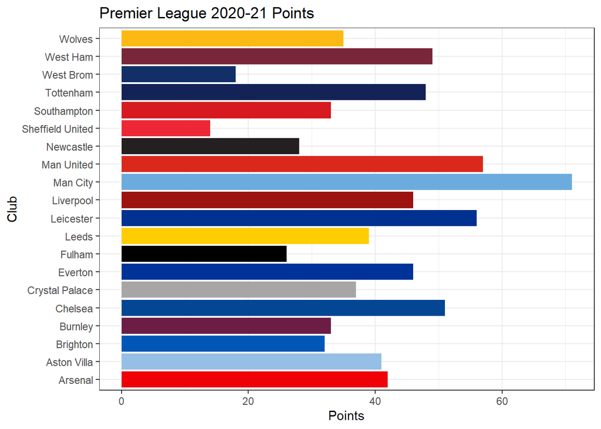

```r
ggplot(league.table, aes(Club, Pts))+
  geom_bar(stat = "identity",
           fill = league.table$Col)+
  theme_bw()+
  coord_flip()+
  labs(x = "Club",
       y = "Points",
       title = "Premier League 2020-21 Points")
```

### Most Goals Scored

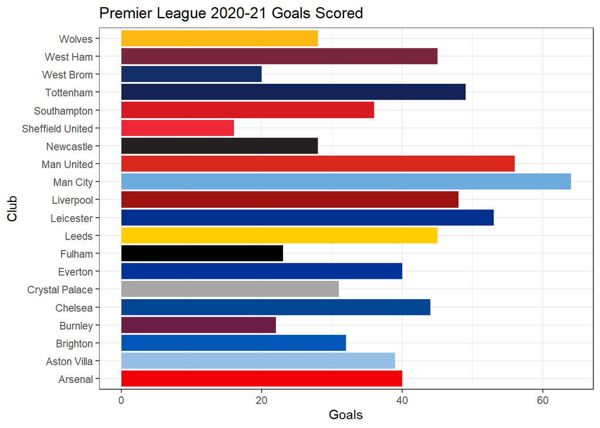

```r
ggplot(league.table, aes(Club, GF))+
  geom_bar(stat = "identity",
           fill = league.table$Col)+
  theme_bw()+
  coord_flip()+
  labs(x = "Club",
       y = "Goals",
       title = "Premier League 2020-21 Goals Scored")
```

### Most Goals Conceded

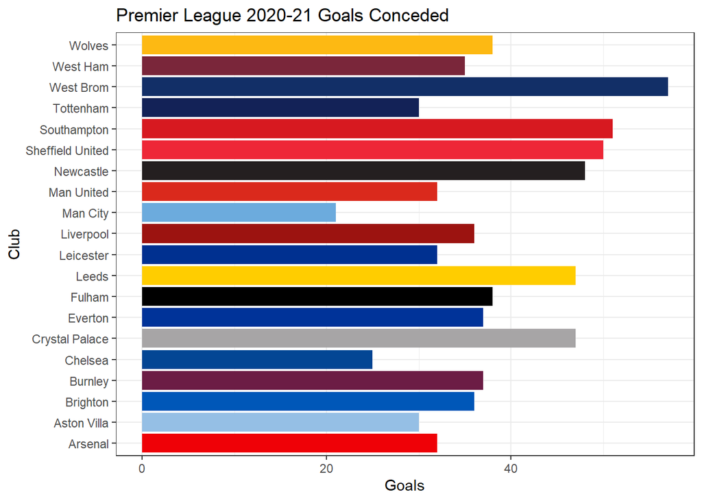

```r
ggplot(league.table, aes(Club, GA))+
  geom_bar(stat = "identity",
           fill = league.table$Col)+
  theme_bw()+
  coord_flip()+
  labs(x = "Club",
       y = "Goals",
       title = "Premier League 2020-21 Goals Conceded")
```

### Points Vs Goals Scored

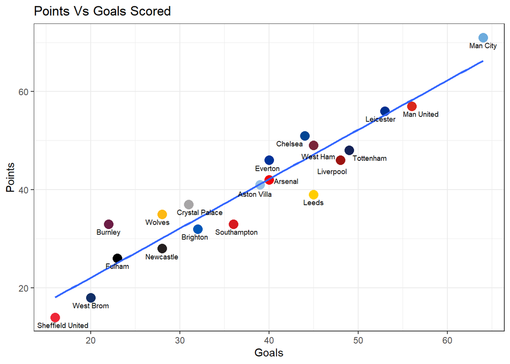

```r
ggplot(league.table, aes(GF, Pts) )+
  geom_point(size = 4, col = league.table$Col)+
  geom_smooth(method = lm, se = F, formula = y ~ x)+
  theme_bw()+
  labs(
    x = "Goals",
    y = "Points",
    title = "Points Vs Goals Scored")+
  geom_text_repel(
    label= league.table$Club,
    nudge_x = 0, nudge_y = -1.0,
    aes(size = 2.5)
  )+
  scale_size_identity()
```

### Points Vs Goals Conceded

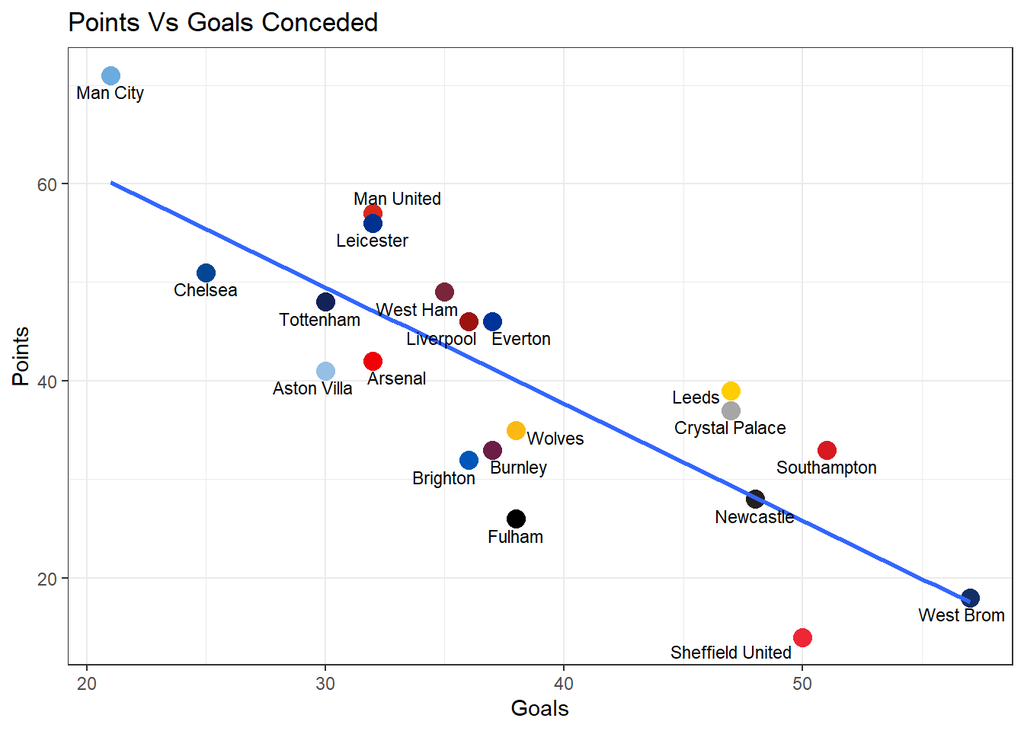

```r
ggplot(league.table, aes(GA, Pts))+
  geom_point(size = 4, col = league.table$Col)+
  geom_smooth(method = lm, se = F, formula = y ~ x)+
  theme_bw()+
  labs(
    x = "Goals",
    y = "Points",
    title = "Points Vs Goals Conceded")+
  geom_text_repel(
    label= league.table$Club,
    nudge_x = 0, nudge_y = -1.0,
    aes(size = 3)
  )+
  scale_size_identity()
```

### Home Performance

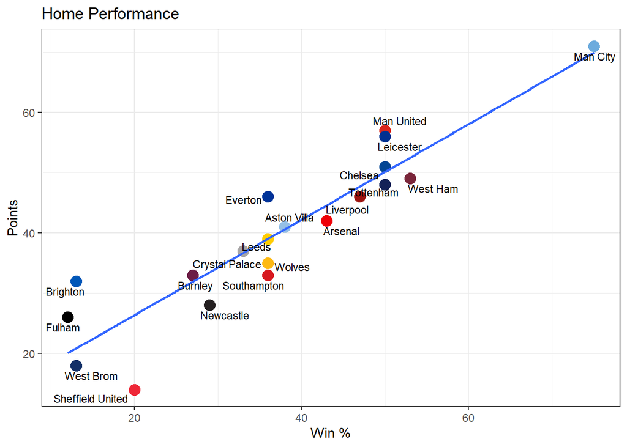

```r
ggplot(league.table, aes(HW.Rate, Pts))+
  geom_point(size = 4, col = league.table$Col)+
  geom_smooth(method = lm, se = FALSE, formula = y ~ x)+
  theme_bw()+
  labs(
    x = "Win %",
    y = "Points",
    title = "Home Performance")+
  geom_text_repel(
    label= league.table$Club,
    nudge_x = 0, nudge_y = -0.25,
    aes(size = 3)
  )+
  scale_size_identity()
```

### Away Performance

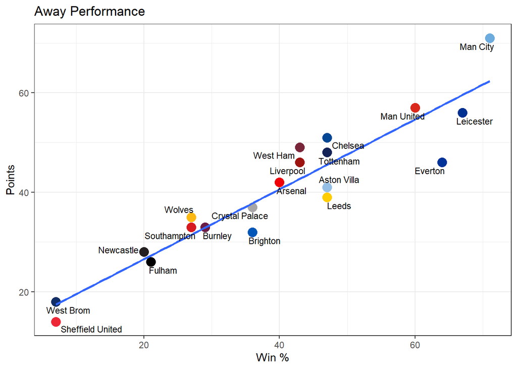

```r
ggplot(league.table, aes(AW.Rate, Pts))+
  geom_point(size = 4, col = league.table$Col)+
  geom_smooth(method = lm, se = FALSE, formula = y ~ x)+
  theme_bw()+
  labs(
    x = "Win %",
    y = "Points",
    title = "Away Performance")+
  geom_text_repel(
    label= league.table$Club,
    nudge_x = 0, nudge_y = -0.25,
    aes(size = 3)
  )+
  scale_size_identity()
```

### Creativity

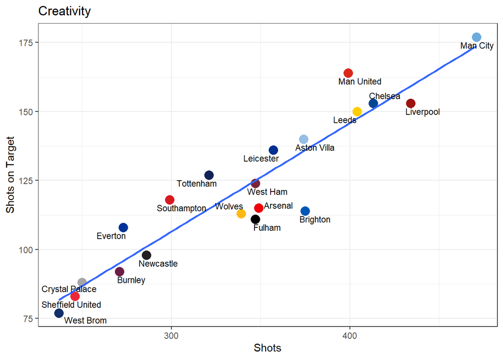

```r
ggplot(league.table, aes(S, ST))+
  geom_point(size = 4, col = league.table$Col)+
  geom_smooth(method = lm, se = FALSE, formula = y ~ x)+
  theme_bw()+
  labs(
    x = "Shots",
    y = "Shots on Target",
    title = "Creativity")+
  geom_text_repel(
    label= league.table$Club,
    nudge_x = 0, nudge_y = -0.25,
    aes(size = 3)
  )+
  scale_size_identity()
```

### Clinical Attacks

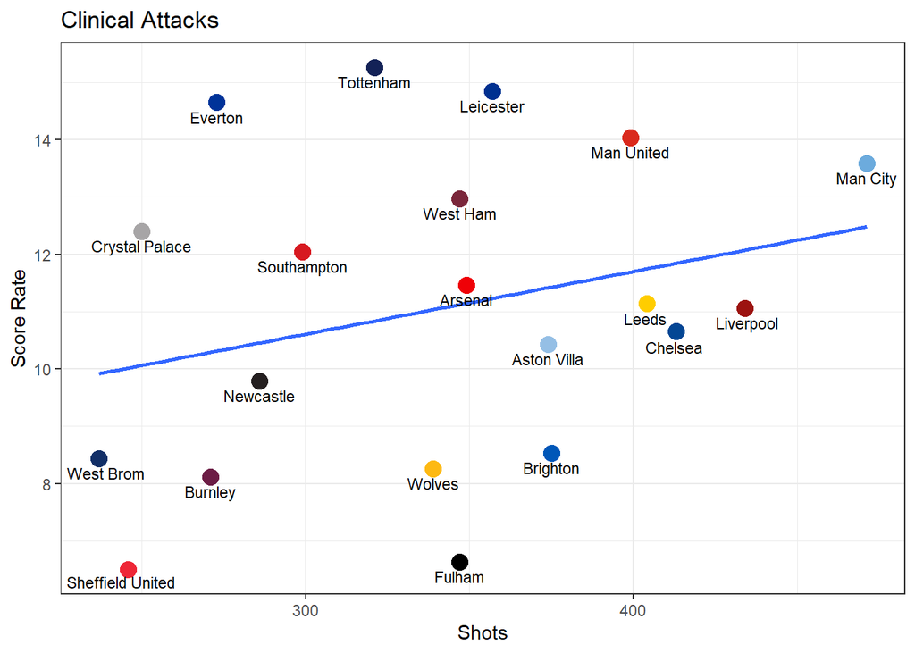

```r
ggplot(league.table, aes(S, (GF/S * 100)))+
  geom_point(size = 4, col = league.table$Col)+
  geom_smooth(method = lm, se = FALSE, formula = y ~ x)+
  theme_bw()+
  labs(
    x = "Shots",
    y = "Score Rate",
    title = "Clinical Attacks")+
  geom_text_repel(
    label= league.table$Club,
    nudge_x = 0, nudge_y = -0.25,
    aes(size = 3)
  )+
  scale_size_identity()
```

### Fair Play / Tactical Fouls

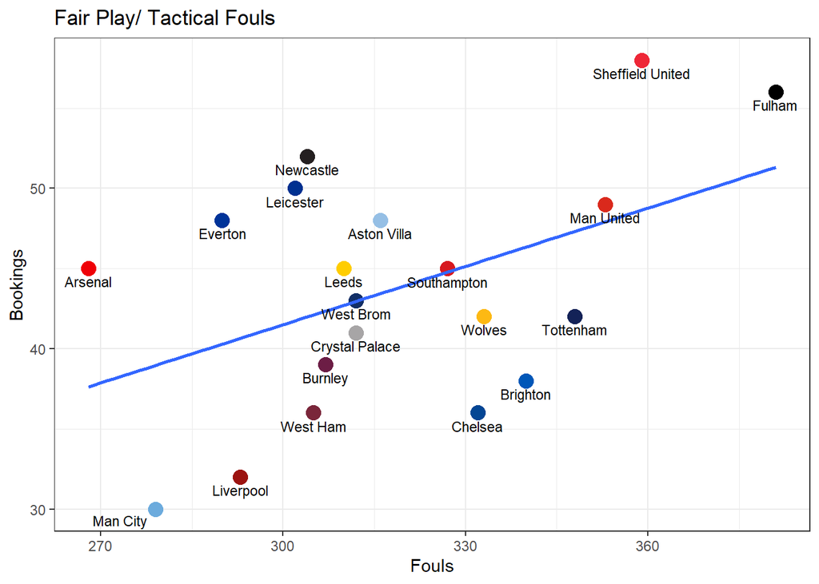

```r
ggplot(league.table, aes(F, B))+
  geom_point(size = 4, col = league.table$Col)+
  geom_smooth(method = lm, se = FALSE, formula = y ~ x)+
  theme_bw()+
  labs(
    x = "Fouls",
    y = "Bookings",
    title = "Fair Play/ Tactical Fouls")+
  geom_text_repel(
    label= league.table$Club,
    nudge_x = 0, nudge_y = -0.25,
    aes(size = 3)
  )+
  scale_size_identity()
```

### Yellow Cards

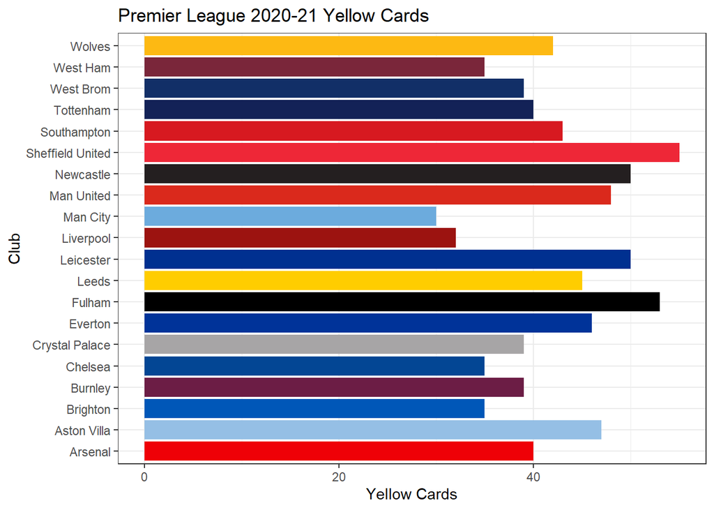

```r
ggplot(league.table, aes(Club, YC))+
  geom_bar(stat = "identity",
           fill = league.table$Col)+
  theme_bw()+
  coord_flip()+
  labs(x = "Club",
       y = "Yellow Cards",
       title = "Premier League 2020-21 Yellow Cards")
```

### Red Cards

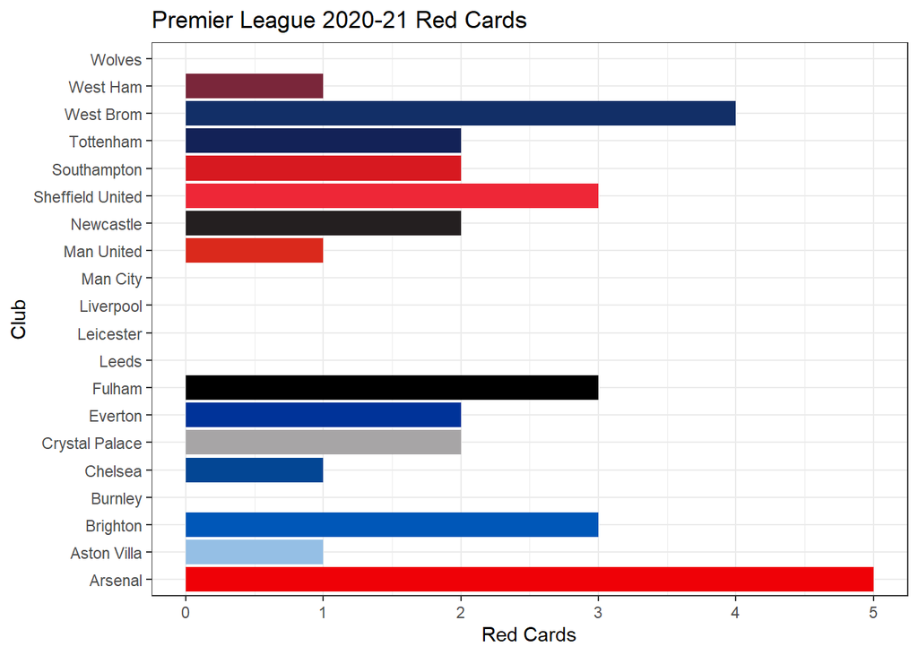

```r
ggplot(league.table, aes(Club, RC))+
  geom_bar(stat = "identity",
           fill = league.table$Col)+
  theme_bw()+
  coord_flip()+
  labs(x = "Club",
       y = "Red Cards",
       title = "Premier League 2020-21 Red Cards")
```